# Hotel Cancellation EDA

## 0.11 **Grouping Methods**

```r
#look into product type
h2_train %>%
  select(product_type,  OTB, OTB_to_be_cxl) %>%
  group_by(product_type) %>%
  summarise(avg_bookings = mean(OTB),
            avg_cancels = mean(OTB_to_be_cxl),
             perc_cxl = (mean(OTB_to_be_cxl)/mean(OTB))*100) %>%
  kable(align = c("c", "c", "c")) %>%
  kable_styling(bootstrap_options = c("striped", "condensed", "bordered")) %>%
  column_spec(1:3, color = "#000000")
```

| product_type | avg_bookings | avg_cancels | perc_cxl |
| --- | --- | --- | --- |
| BUSINESS TRAVEL AGENCIES | 30.880963 | 2.6655859 | 8.631809 |
| CORPORATE | 109.244026 | 9.3304228 | 8.540900 |
| FENCED | 62.994485 | 1.0082721 | 1.600572 |
| GOVERNMENT | 6.232752 | 1.1319181 | 18.160808 |
| GROUP | 154.425622 | 9.0445800 | 5.856917 |
| MEMBERSHIP MARKETING | 47.562442 | 4.2437558 | 8.922493 |
| OPAQUE | 152.664522 | 2.7389706 | 1.794111 |
| OTHER | 2.869565 | 0.0480072 | 1.672980 |
| TACTICAL MARKETING | 9.598595 | 0.4259910 | 4.438055 |
| UNFENCED | 129.681066 | 12.5280331 | 9.660649 |
| WHOLESALE | 34.522518 | 3.3350184 | 9.660414 |

This is very different from the ATL Hotel as the percentage of cancellations is less spread out. It is evident that the groupings for product type will be different from the first hotel. There are also different product types that could affect pricing differently. One group based off of cancellations is as follows.

- Fenced, opaque, other
- tactical marketing, group, corporate
- business travel agencies, membership marketing, unfenced, wholesale
- government

```r
#make these groups
h2_train_1 <- h2_train %>%
      mutate(prod_group_perc = case_when(product_type == 'OPAQUE' ~ 'OP/FENC/OTH',
                                         product_type == 'FENCED' ~ 'OP/FENC/OTH',
                                         product_type == 'CORPORATE' ~ 'CORP/GROUP/TACT',
                                         product_type == 'BUSINESS TRAVEL AGENCIES' ~ 'UNF/WHOLE/MEM/BUS',
                                         product_type == 'GROUP' ~ 'CORP/GROUP/TACT',
                                         product_type == 'TACTICAL MARKETING' ~ 'CORP/GROUP/TACT',
                                         product_type == 'MEMBERSHIP MARKETING' ~ 'UNF/WHOLE/MEM/BUS',
                                         product_type == 'OTHER' ~ 'OP/FENC/OTH',
                                         product_type == 'UNFENCED' ~ 'UNF/WHOLE/MEM/BUS',
                                         product_type == 'GOVERNMENT' ~ 'GOVERNMENT',
                                         product_type == 'WHOLESALE' ~ 'UNF/WHOLE/MEM/BUS'))
```

```r
#above by day of week
h2_train %>%
  select(product_type, day_of_week, OTB, OTB_to_be_cxl) %>%
  group_by(product_type, day_of_week) %>%
  summarise(avg_bookings = mean(OTB),
            avg_cancels = mean(OTB_to_be_cxl)) %>%
  arrange(desc(avg_bookings)) %>%
  kable(align = c("c", "c", "c", "c")) %>%
  kable_styling(bootstrap_options = c("striped", "condensed", "bordered")) %>%
  column_spec(1:4, color = "#000000")
```

| product_type | day_of_week | avg_bookings | avg_cancels |
| --- | --- | --- | --- |
| OPAQUE | 7 | 252.675000 | 3.7718750 |
| GROUP | 3 | 222.716312 | 13.0035461 |
| OPAQUE | 6 | 209.412500 | 3.8093750 |
| GROUP | 4 | 208.360129 | 11.6913183 |
| GROUP | 5 | 187.571875 | 11.5312500 |
| GROUP | 2 | 179.720149 | 10.7910448 |
| CORPORATE | 3 | 162.430556 | 14.1180556 |
| CORPORATE | 4 | 157.537500 | 14.1312500 |
| OPAQUE | 1 | 154.571875 | 2.8406250 |
| UNFENCED | 7 | 142.862500 | 13.3312500 |
| OPAQUE | 5 | 138.471875 | 2.4812500 |
| CORPORATE | 2 | 136.878472 | 11.8506944 |
| UNFENCED | 3 | 134.149306 | 12.8298611 |
| UNFENCED | 5 | 133.650000 | 13.9500000 |
| UNFENCED | 4 | 131.143750 | 12.6125000 |
| UNFENCED | 6 | 128.543750 | 12.1937500 |
| UNFENCED | 2 | 128.458333 | 12.0694444 |
| CORPORATE | 5 | 121.943750 | 10.4750000 |
| GROUP | 1 | 112.941935 | 6.7645161 |
| UNFENCED | 1 | 109.284375 | 10.6937500 |
| OPAQUE | 2 | 105.489583 | 2.2430556 |
| OPAQUE | 3 | 101.017361 | 2.2881944 |
| OPAQUE | 4 | 97.131250 | 1.6437500 |
| GROUP | 6 | 96.643750 | 5.5875000 |
| FENCED | 7 | 96.512500 | 1.3031250 |
| FENCED | 6 | 91.218750 | 1.4000000 |
| MEMBERSHIP MARKETING | 7 | 87.978125 | 7.5656250 |
| GROUP | 7 | 85.465625 | 4.7000000 |
| CORPORATE | 1 | 79.415625 | 6.7250000 |
| MEMBERSHIP MARKETING | 6 | 73.246875 | 6.1437500 |
| FENCED | 5 | 65.518750 | 1.0531250 |
| CORPORATE | 6 | 60.659375 | 4.3625000 |
| FENCED | 1 | 60.521875 | 0.6125000 |
| CORPORATE | 7 | 53.925000 | 4.3812500 |
| BUSINESS TRAVEL AGENCIES | 4 | 49.606250 | 4.6062500 |
| BUSINESS TRAVEL AGENCIES | 3 | 48.791667 | 4.3888889 |
| FENCED | 4 | 45.428125 | 1.0937500 |
| MEMBERSHIP MARKETING | 1 | 45.012500 | 4.5656250 |
| FENCED | 2 | 40.663194 | 0.7708333 |
| MEMBERSHIP MARKETING | 5 | 39.500000 | 3.8125000 |
| BUSINESS TRAVEL AGENCIES | 2 | 39.104167 | 3.3159722 |
| BUSINESS TRAVEL AGENCIES | 5 | 37.078125 | 3.1593750 |
| WHOLESALE | 2 | 36.510417 | 3.2847222 |
| WHOLESALE | 7 | 36.246875 | 3.7250000 |
| FENCED | 3 | 36.184028 | 0.7777778 |
| WHOLESALE | 1 | 35.231250 | 2.6312500 |
| WHOLESALE | 6 | 35.031250 | 3.7093750 |
| WHOLESALE | 3 | 34.097222 | 3.2430556 |
| WHOLESALE | 5 | 32.603125 | 3.5937500 |
| WHOLESALE | 4 | 32.093750 | 3.1437500 |
| MEMBERSHIP MARKETING | 4 | 29.384375 | 2.4906250 |
| MEMBERSHIP MARKETING | 2 | 26.500000 | 2.4637681 |
| MEMBERSHIP MARKETING | 3 | 26.143357 | 2.2027972 |
| BUSINESS TRAVEL AGENCIES | 1 | 20.475000 | 1.4187500 |
| BUSINESS TRAVEL AGENCIES | 6 | 12.336538 | 1.1121795 |
| TACTICAL MARKETING | 6 | 10.865772 | 0.2885906 |
| TACTICAL MARKETING | 5 | 10.759582 | 0.3658537 |
| TACTICAL MARKETING | 3 | 10.640816 | 0.3918367 |
| BUSINESS TRAVEL AGENCIES | 7 | 10.347267 | 0.8038585 |
| GOVERNMENT | 4 | 10.196429 | 1.5625000 |
| TACTICAL MARKETING | 2 | 9.387454 | 0.6826568 |
| TACTICAL MARKETING | 7 | 9.252396 | 0.4792332 |
| TACTICAL MARKETING | 4 | 9.050725 | 0.2572464 |
| GOVERNMENT | 3 | 8.276923 | 1.5179487 |
| TACTICAL MARKETING | 1 | 7.455445 | 0.5148515 |
| GOVERNMENT | 2 | 6.354037 | 1.5527950 |
| GOVERNMENT | 5 | 5.963542 | 0.8802083 |
| GOVERNMENT | 1 | 4.432432 | 0.6108108 |
| OTHER | 3 | 4.206897 | 0.0000000 |
| OTHER | 4 | 3.961832 | 0.0000000 |
| OTHER | 2 | 3.909910 | 0.0000000 |
| GOVERNMENT | 6 | 3.861111 | 1.0500000 |
| GOVERNMENT | 7 | 3.516484 | 0.6923077 |
| OTHER | 5 | 3.393548 | 0.0000000 |
| OTHER | 1 | 2.461539 | 0.0000000 |
| OTHER | 7 | 2.295082 | 0.1065574 |
| OTHER | 6 | 1.628906 | 0.1054688 |

Opaque has the highest number of groupings on Sunday and Saturday. This could mean that the the NY hotel has less demand for Sundays so they sell last minute on this day. The middle of the week for group has the next highest average bookings.

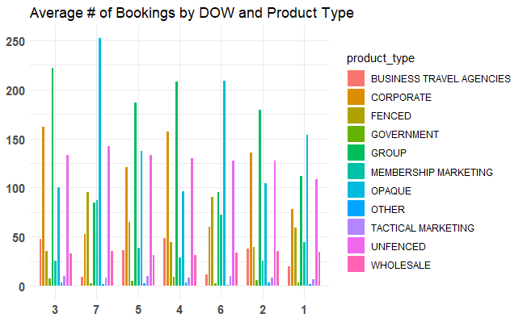

```r
#bookings by day of week and product type
h2_train %>%
  select(day_of_week, product_type, OTB) %>%
  group_by(day_of_week, product_type) %>%
  summarise(avg_bookings = mean(OTB)) %>%
  ggplot(aes(x = reorder(day_of_week, -avg_bookings), y = avg_bookings, fill = product_type)) +
           geom_bar(stat = "identity", width = .8, color = "white", position = "dodge") +
           theme_minimal() +
           theme(axis.title = element_blank(),
                axis.line.y = element_blank(),
                axis.ticks.y = element_blank(),
                axis.text.y = element_text(size = 11, face = "bold"),
                axis.text.x = element_text(size = 11, face = "bold")) +
           ggtitle("Average # of Bookings by DOW and Product Type")
```

Again, this hotel is very different from ATL. Opaque has a lot more bookings, especially on fridays and saturdays. Other, government, and tactial marketing are very small categories and should be grouped with other product types. It seems like this hotel houses a lot of business since corporate and group are so high and they dont have as many staying on fridays and saturday nights.

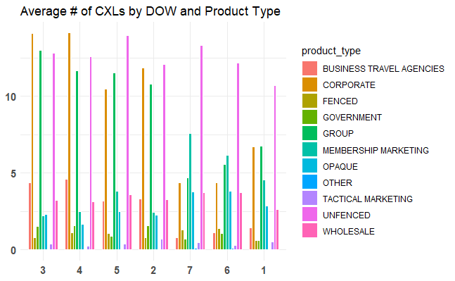

```r
#above by cancellations
h2_train %>%
  select(day_of_week, product_type, OTB_to_be_cxl) %>%
  group_by(day_of_week, product_type) %>%
  summarise(avg_cxl = mean(OTB_to_be_cxl)) %>%
  ggplot(aes(x = reorder(day_of_week, -avg_cxl), y = avg_cxl, fill = product_type)) +
           geom_bar(stat = "identity", width = .8, color = "white", position = "dodge") +
           theme_minimal() +
           theme(axis.title = element_blank(),
                axis.line.y = element_blank(),
                axis.ticks.y = element_blank(),
                axis.text.y = element_text(size = 11, face = "bold"),
                axis.text.x = element_text(size = 11, face = "bold")) +
           ggtitle("Average # of CXLs by DOW and Product Type")
```

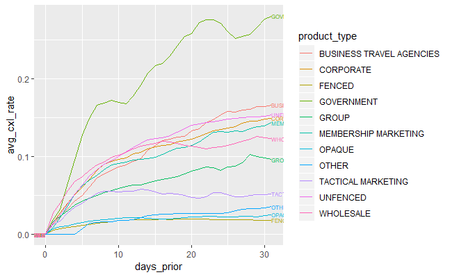

```r
h2_train %>%
  select(product_type, days_prior, OTB, OTB_to_be_cxl) %>%
  group_by(days_prior, product_type) %>%
  summarise(avg_cxl_rate = mean(OTB_to_be_cxl)/mean(OTB)) %>%
  ggplot()+
  geom_line(aes(x=days_prior, y=avg_cxl_rate, color = product_type))+
  geom_dl(aes(label = product_type, x=days_prior, y=avg_cxl_rate, color = product_type), method = list(dl.combine("first.points", "last.points"), cex=0.5))
```

Again, it seems as though truncating the days prior is a good idea for this hotel again. Let’s first look into that.

```r
h2_train %>%
  select(days_prior, daily_cxl_bookings) %>%
  group_by(days_prior) %>%
  summarize(num = sum(daily_cxl_bookings)) %>%
  kable(align = c("c", "c", "c", "c")) %>%
  kable_styling(bootstrap_options = c("striped", "condensed", "bordered")) %>%
  column_spec(1:2, color = "#000000")
```

| days_prior | num |
| --- | --- |
| 0 | 1125 |
| 1 | 686 |
| 2 | 774 |
| 3 | 735 |
| 4 | 672 |
| 5 | 626 |
| 6 | 605 |
| 7 | 503 |
| 8 | 384 |
| 9 | 308 |
| 10 | 271 |
| 11 | 286 |
| 12 | 249 |
| 13 | 271 |
| 14 | 222 |
| 15 | 200 |
| 16 | 177 |
| 17 | 182 |
| 18 | 176 |
| 19 | 201 |
| 20 | 259 |
| 21 | 304 |
| 22 | 325 |
| 23 | 294 |
| 24 | 251 |
| 25 | 179 |
| 26 | 152 |
| 27 | 200 |
| 28 | 181 |
| 29 | 168 |
| 30 | 149 |
| 31 | 102 |

- The amount of observations for each days prior goes down significantly after day 31. We will truncate the days prior here.

```r
h2_train <- h2_train %>%
  filter(days_prior < 31)
```

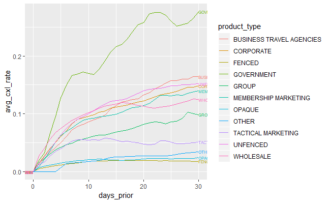

```r
h2_train %>%
  select(product_type, days_prior, OTB, OTB_to_be_cxl) %>%
  filter(days_prior <= 31) %>%
  group_by(days_prior, product_type) %>%
  summarise(avg_cxl_rate = mean(OTB_to_be_cxl)/mean(OTB)) %>%
  ggplot()+
  geom_line(aes(x=days_prior, y=avg_cxl_rate, color = product_type))+
  geom_dl(aes(label = product_type, x=days_prior, y=avg_cxl_rate, color = product_type), method = list(dl.combine("first.points", "last.points"), cex=0.5))
```

A lot of very similar curves. Another grouping of product type is as follows.

```r
# number of cancellations in each product type
h2_train %>%
  select(product_type, daily_cxl_bookings) %>%
  group_by(product_type) %>%
  summarize(num = sum(daily_cxl_bookings)) %>%
  kable(align = c("c", "c", "c", "c")) %>%
  kable_styling(bootstrap_options = c("striped", "condensed", "bordered")) %>%
  column_spec(1:2, color = "#000000")
```

| product_type | num |
| --- | --- |
| BUSINESS TRAVEL AGENCIES | 745 |
| CORPORATE | 2839 |
| FENCED | 118 |
| GOVERNMENT | 110 |
| GROUP | 2692 |
| MEMBERSHIP MARKETING | 732 |
| OPAQUE | 651 |
| OTHER | 2 |
| TACTICAL MARKETING | 94 |
| UNFENCED | 2600 |
| WHOLESALE | 532 |

```r
#make this a group
h2_train_2 <- h2_train %>%
      mutate(prod_group_behav = case_when(product_type == 'OPAQUE' ~ 'OTH/OPA/FEN',
                                         product_type == 'FENCED' ~ 'OTH/OPA/FEN',
                                         product_type == 'CORPORATE' ~ 'CORP/MEMB/WHOLE',
                                         product_type == 'BUSINESS TRAVEL AGENCIES' ~ 'BTA/UNFEN/CORP/MM',
                                         product_type == 'GROUP' ~ 'GROUP',
                                         product_type == 'TACTICAL MARKETING' ~ 'TACT/WHOLE',
                                         product_type == 'MEMBERSHIP MARKETING' ~ 'BTA/UNFEN/CORP/MM',
                                         product_type == 'OTHER' ~ 'OTH/OPA/FEN',
                                         product_type == 'UNFENCED' ~ 'BTA/UNFEN/CORP/MM',
                                         product_type == 'GOVERNMENT' ~ 'GOVERNMENT',
                                         product_type == 'WHOLESALE' ~ 'TACT/WHOLE'))
#truncate days prior to 32
h2_train_2 <- h2_train_2 %>%
            filter(days_prior <= 31)
```

## 0.12 **Further Analysis**

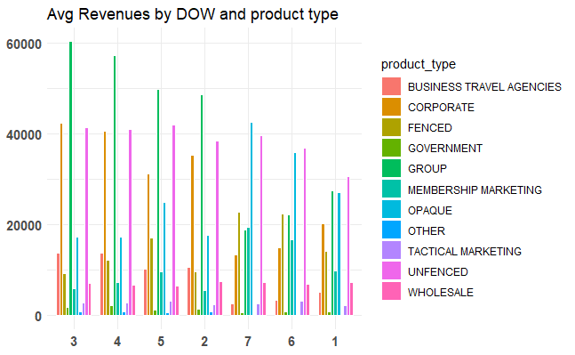

```r
#revenue by day of week
h2_train %>%
  select(day_of_week, product_type, OTB_rev) %>%
  group_by(day_of_week, product_type) %>%
  summarise(avg_rev = mean(OTB_rev)) %>%
  ggplot(aes(x = reorder(day_of_week, -avg_rev), y = avg_rev, fill = product_type)) +
           geom_bar(stat = "identity", width = .8, color = "white", position = "dodge") +
           theme_minimal() +
           theme(axis.title = element_blank(),
                axis.line.y = element_blank(),
                axis.ticks.y = element_blank(),
                axis.text.y = element_text(size = 11, face = "bold"),
                axis.text.x = element_text(size = 11, face = "bold")) +
           ggtitle("Avg Revenues by DOW and product type")
```

Group is very low on friday, saturday, and sunday but hotel does a good job by supplemeniting this with opaque. It would be interesting to see this price average.

```r
#look into days of week  with revenue and pricing
h2_train %>%
  select(OTB, OTB_to_be_cxl, OTB_rev, day_of_week) %>%
  group_by(day_of_week) %>%
  summarise(avg_bookings = mean(OTB),
            avg_cancels = mean(OTB_to_be_cxl),
            avg_otb_rev = mean(OTB_rev),
            avg_price = mean(OTB_rev)/ mean(OTB)) %>%
  arrange(desc(avg_otb_rev)) %>%
  kable(align = c("c", "c", "c", "c")) %>%
  kable_styling(bootstrap_options = c("striped", "condensed", "bordered")) %>%
  column_spec(1:5, color = "#000000")
```

| day_of_week | avg_bookings | avg_cancels | avg_otb_rev | avg_price |
| --- | --- | --- | --- | --- |
| 3 | 79.38709 | 5.462121 | 20183.71 | 254.2443 |
| 4 | 77.53834 | 5.295374 | 19963.77 | 257.4697 |
| 5 | 78.15888 | 5.112150 | 19522.61 | 249.7811 |
| 2 | 71.82992 | 4.866862 | 17708.05 | 246.5275 |
| 7 | 76.53179 | 3.945506 | 16482.30 | 215.3654 |
| 6 | 70.87586 | 3.823198 | 15801.44 | 222.9452 |
| 1 | 64.41724 | 3.753537 | 14659.89 | 227.5771 |

Average prices are relatively the same for all days of week. Is this different by product type?

```r
h2_train %>%
  select(OTB, OTB_to_be_cxl, OTB_rev, day_of_week, product_type) %>%
  group_by(day_of_week, product_type) %>%
  summarise(avg_bookings = mean(OTB),
            avg_cancels = mean(OTB_to_be_cxl),
            avg_otb_rev = mean(OTB_rev),
            avg_price = mean(OTB_rev)/ mean(OTB)) %>%
  arrange(desc(avg_price)) %>%
  kable(align = c("c", "c", "c", "c")) %>%
  kable_styling(bootstrap_options = c("striped", "condensed", "bordered")) %>%
  column_spec(1:6, color = "#000000")
```

| day_of_week | product_type | avg_bookings | avg_cancels | avg_otb_rev | avg_price |
| --- | --- | --- | --- | --- | --- |
| 5 | UNFENCED | 135.435484 | 14.0000000 | 41886.123935 | 309.269940 |
| 4 | UNFENCED | 133.019355 | 12.6677419 | 41038.105097 | 308.512285 |
| 4 | TACTICAL MARKETING | 9.104089 | 0.2565056 | 2776.605948 | 304.984484 |
| 3 | UNFENCED | 135.903226 | 12.8422939 | 41381.312760 | 304.491027 |
| 6 | TACTICAL MARKETING | 10.937931 | 0.2896552 | 3242.904621 | 296.482453 |
| 2 | UNFENCED | 130.150538 | 12.0573477 | 38506.486738 | 295.861142 |
| 5 | TACTICAL MARKETING | 10.817857 | 0.3678571 | 3163.524321 | 292.435394 |
| 6 | UNFENCED | 130.067742 | 12.1967742 | 36916.071935 | 283.821887 |
| 7 | TACTICAL MARKETING | 9.351974 | 0.4802632 | 2642.688717 | 282.580855 |
| 1 | TACTICAL MARKETING | 7.498305 | 0.5186441 | 2116.611525 | 282.278662 |
| 3 | BUSINESS TRAVEL AGENCIES | 49.620072 | 4.4193548 | 13812.912652 | 278.373492 |
| 1 | UNFENCED | 110.448387 | 10.6387097 | 30655.217677 | 277.552425 |
| 7 | UNFENCED | 144.487097 | 13.3548387 | 39635.863516 | 274.321129 |
| 4 | BUSINESS TRAVEL AGENCIES | 50.474193 | 4.6290323 | 13789.224097 | 273.193550 |
| 4 | GROUP | 210.498350 | 11.7326733 | 57232.615379 | 271.891041 |
| 3 | TACTICAL MARKETING | 10.677824 | 0.3891213 | 2870.094142 | 268.790165 |
| 5 | BUSINESS TRAVEL AGENCIES | 37.809677 | 3.1838710 | 10162.704097 | 268.785792 |
| 2 | GROUP | 181.389313 | 10.8282443 | 48619.319657 | 268.038502 |
| 3 | GROUP | 225.018182 | 13.0618182 | 60287.396327 | 267.922333 |
| 6 | BUSINESS TRAVEL AGENCIES | 12.511551 | 1.0957096 | 3350.247690 | 267.772369 |
| 2 | BUSINESS TRAVEL AGENCIES | 39.749104 | 3.3369176 | 10555.422437 | 265.551205 |
| 4 | FENCED | 45.867742 | 1.0935484 | 12155.910903 | 265.020914 |
| 2 | TACTICAL MARKETING | 9.424242 | 0.6856061 | 2478.060606 | 262.945338 |
| 5 | GROUP | 190.722581 | 11.6032258 | 49838.916710 | 261.316287 |
| 5 | FENCED | 66.070968 | 1.0580645 | 17042.058871 | 257.935663 |
| 3 | CORPORATE | 165.806452 | 14.2903226 | 42357.888387 | 255.465864 |
| 7 | BUSINESS TRAVEL AGENCIES | 10.490066 | 0.7913907 | 2658.762020 | 253.455218 |
| 2 | CORPORATE | 139.691756 | 11.9677419 | 35252.169140 | 252.356832 |
| 4 | CORPORATE | 160.916129 | 14.3161290 | 40536.548290 | 251.911033 |
| 5 | CORPORATE | 124.380645 | 10.5741935 | 31279.939710 | 251.485588 |
| 3 | FENCED | 36.462366 | 0.7777778 | 9156.952007 | 251.134337 |
| 1 | CORPORATE | 80.980645 | 6.8000000 | 20234.827258 | 249.872389 |
| 1 | BUSINESS TRAVEL AGENCIES | 20.800000 | 1.4129032 | 5118.427129 | 246.078227 |
| 4 | MEMBERSHIP MARKETING | 29.816129 | 2.5032258 | 7323.472419 | 245.621167 |
| 7 | CORPORATE | 54.838710 | 4.4193548 | 13412.137613 | 244.574274 |
| 6 | FENCED | 91.864516 | 1.4129032 | 22430.224581 | 244.166361 |
| 5 | MEMBERSHIP MARKETING | 40.009677 | 3.8161290 | 9730.692064 | 243.208461 |
| 1 | GROUP | 114.261589 | 6.6490066 | 27565.479867 | 241.248875 |
| 6 | CORPORATE | 61.651613 | 4.3903226 | 14866.575323 | 241.138465 |
| 2 | FENCED | 40.949821 | 0.7706093 | 9714.851756 | 237.237955 |
| 7 | FENCED | 97.170968 | 1.3096774 | 22854.351387 | 235.197322 |
| 1 | FENCED | 60.809677 | 0.6129032 | 14183.541193 | 233.244802 |
| 3 | MEMBERSHIP MARKETING | 26.366906 | 2.1942446 | 5958.924640 | 226.000143 |
| 6 | MEMBERSHIP MARKETING | 74.009677 | 6.1258065 | 16601.102645 | 224.309891 |
| 6 | GROUP | 98.580645 | 5.6677419 | 22086.195742 | 224.041907 |
| 4 | GOVERNMENT | 10.200000 | 1.5545455 | 2236.416864 | 219.256555 |
| 7 | MEMBERSHIP MARKETING | 88.848387 | 7.5419355 | 19404.470419 | 218.399805 |
| 7 | GROUP | 87.258065 | 4.7741935 | 18945.957903 | 217.125580 |
| 1 | MEMBERSHIP MARKETING | 45.361290 | 4.5290323 | 9771.072484 | 215.405523 |
| 2 | GOVERNMENT | 6.369427 | 1.5477707 | 1356.942675 | 213.040000 |
| 6 | GOVERNMENT | 3.841808 | 1.0338983 | 817.151412 | 212.699706 |
| 3 | GOVERNMENT | 8.229167 | 1.5000000 | 1742.697917 | 211.770886 |
| 5 | GOVERNMENT | 5.952381 | 0.8624339 | 1259.312169 | 211.564444 |
| 7 | GOVERNMENT | 3.502793 | 0.6759777 | 730.804469 | 208.634769 |
| 3 | WHOLESALE | 34.322581 | 3.2401434 | 7159.534050 | 208.595447 |
| 1 | GOVERNMENT | 4.425414 | 0.5911602 | 921.037293 | 208.124532 |
| 4 | WHOLESALE | 32.332258 | 3.1483871 | 6685.548387 | 206.776414 |
| 2 | WHOLESALE | 36.741935 | 3.2867384 | 7548.792115 | 205.454395 |
| 2 | MEMBERSHIP MARKETING | 26.667910 | 2.4440299 | 5450.313508 | 204.377224 |
| 2 | OTHER | 3.889908 | 0.0000000 | 793.783945 | 204.062382 |
| 1 | WHOLESALE | 35.461290 | 2.6290323 | 7217.177419 | 203.522696 |
| 7 | WHOLESALE | 36.500000 | 3.7258065 | 7384.538710 | 202.316129 |
| 5 | WHOLESALE | 32.838710 | 3.5903226 | 6602.861290 | 201.069450 |
| 6 | WHOLESALE | 35.306452 | 3.7129032 | 6977.380645 | 197.623390 |
| 3 | OTHER | 4.184210 | 0.0000000 | 813.084825 | 194.322159 |
| 4 | OTHER | 3.937985 | 0.0000000 | 737.084496 | 187.173032 |
| 5 | OTHER | 3.350649 | 0.0000000 | 601.896494 | 179.635775 |
| 5 | OPAQUE | 140.012903 | 2.4870968 | 24947.560807 | 178.180441 |
| 4 | OPAQUE | 98.183871 | 1.6483871 | 17285.846129 | 176.055863 |
| 1 | OPAQUE | 155.880645 | 2.8580645 | 27119.343516 | 173.975053 |
| 3 | OPAQUE | 102.050179 | 2.2724014 | 17315.589964 | 169.677213 |
| 6 | OPAQUE | 211.877419 | 3.8193548 | 35949.467581 | 169.671066 |
| 7 | OPAQUE | 255.977419 | 3.8000000 | 42519.394677 | 166.106037 |
| 2 | OPAQUE | 106.623656 | 2.2365591 | 17637.677240 | 165.419926 |
| 1 | OTHER | 2.461539 | 0.0000000 | 29.100000 | 11.821875 |
| 7 | OTHER | 2.323529 | 0.1050420 | 9.552143 | 4.111049 |
| 6 | OTHER | 1.640000 | 0.1040000 | 0.016400 | 0.010000 |

```r
#look into days prior with revenue and pricing
h2_train %>%
  select(OTB, OTB_to_be_cxl, OTB_rev, days_prior) %>%
  group_by(days_prior) %>%
  summarise(avg_bookings = mean(OTB),
            avg_cancels = mean(OTB_to_be_cxl),
            avg_otb_rev = mean(OTB_rev),
            avg_price = mean(OTB_rev)/ mean(OTB)) %>%
  arrange(desc(avg_otb_rev)) %>%
  kable(align = c("c", "c", "c", "c")) %>%
  kable_styling(bootstrap_options = c("striped", "condensed", "bordered")) %>%
  column_spec(1:5, color = "#000000")
```

| days_prior | avg_bookings | avg_cancels | avg_otb_rev | avg_price |
| --- | --- | --- | --- | --- |
| 0 | 103.62881 | 0.000000 | 24709.15 | 238.4390 |
| 1 | 102.32083 | 1.327778 | 24449.96 | 238.9538 |
| 2 | 100.35007 | 2.107392 | 24053.36 | 239.6945 |
| 3 | 98.47759 | 2.969188 | 23678.68 | 240.4474 |
| 4 | 96.25770 | 3.693277 | 23183.78 | 240.8512 |
| 5 | 94.18233 | 4.242637 | 22675.79 | 240.7648 |
| 6 | 91.86761 | 4.728169 | 22105.45 | 240.6229 |
| 7 | 89.27581 | 5.097595 | 21455.65 | 240.3299 |
| 8 | 86.84637 | 5.345662 | 20842.31 | 239.9905 |
| 9 | 84.35755 | 5.417379 | 20218.75 | 239.6792 |
| 10 | 82.72818 | 5.516452 | 19821.29 | 239.5953 |
| 11 | 81.22414 | 5.599138 | 19459.91 | 239.5829 |
| 12 | 79.49784 | 5.684892 | 19038.57 | 239.4854 |
| 13 | 77.49062 | 5.652237 | 18529.21 | 239.1155 |
| 14 | 75.17562 | 5.648766 | 17943.15 | 238.6832 |
| 15 | 72.98097 | 5.578331 | 17392.61 | 238.3170 |
| 16 | 70.77467 | 5.488954 | 16848.31 | 238.0556 |
| 17 | 68.58789 | 5.397341 | 16323.61 | 237.9955 |
| 18 | 67.20833 | 5.430059 | 15996.25 | 238.0099 |
| 19 | 65.51198 | 5.420659 | 15596.32 | 238.0682 |
| 20 | 63.37688 | 5.381381 | 15086.16 | 238.0388 |
| 21 | 60.65663 | 5.228916 | 14433.34 | 237.9515 |
| 22 | 57.85498 | 5.077039 | 13756.06 | 237.7680 |
| 23 | 55.38088 | 4.905918 | 13175.48 | 237.9066 |
| 24 | 53.33588 | 4.729771 | 12706.42 | 238.2340 |
| 25 | 51.86790 | 4.648233 | 12362.74 | 238.3504 |
| 26 | 50.76899 | 4.573643 | 12104.54 | 238.4238 |
| 27 | 49.68069 | 4.540498 | 11842.36 | 238.3695 |
| 28 | 48.66667 | 4.560250 | 11602.52 | 238.4080 |
| 29 | 47.47956 | 4.443396 | 11335.07 | 238.7357 |
| 30 | 46.55238 | 4.373016 | 11128.69 | 239.0575 |

Days prior again follows a relatively linear relationship.

```r
#add price to h2_train
h2_train <-  h2_train %>%
  mutate(price = OTB_rev/OTB)
```

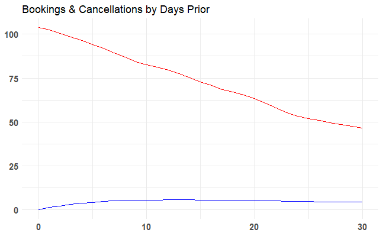

```r
h2_train %>%
  select(days_prior, OTB, OTB_to_be_cxl, OTB_rev) %>%
  group_by(days_prior) %>%
  summarise(avg_net_rev = mean(OTB_rev),
            avg_bookings = mean(OTB),
            avg_cxl = mean(OTB_to_be_cxl)) %>%
  ggplot() +
  geom_line(aes(x = days_prior, y = avg_bookings), color = "red") +
  geom_line(aes(x = days_prior, y = avg_cxl), color = "blue") +
           theme_minimal() +
           theme(axis.title = element_blank(),
                axis.line.y = element_blank(),
                axis.ticks.y = element_blank(),
                axis.text.y = element_text(size = 11, face = "bold"),
                axis.text.x = element_text(size = 11, face = "bold")) +
           ggtitle("Bookings & Cancellations by Days Prior")
```

This has a very similar curve to it that Hotel 1 has.

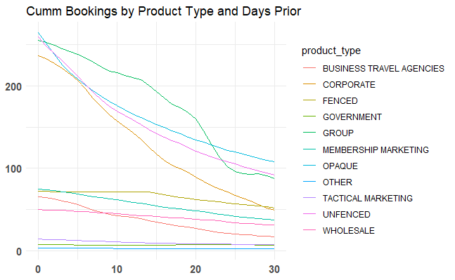

```r
h2_train %>%
  select(days_prior, cummulative_gross_bookings, product_type) %>%
  group_by(days_prior, product_type) %>%
  summarise(avg_bookings = mean(cummulative_gross_bookings)) %>%
  ggplot() +
  geom_line(aes(x = days_prior, y = avg_bookings,  color = product_type)) +
           theme_minimal() +
           theme(axis.title = element_blank(),
                axis.line.y = element_blank(),
                axis.ticks.y = element_blank(),
                axis.text.y = element_text(size = 11, face = "bold"),
                axis.text.x = element_text(size = 11, face = "bold")) +
           ggtitle("Cumm Bookings by Product Type and Days Prior")
```

While some of the groups show an inverse relationship with cummulative bookings and days prior, many show a very steady cummulative bookings. This means that there are not many last minute bookings.

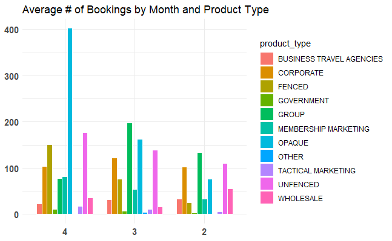

```r
#How does month affect bookings and cancellations
h2_train$month = month(h2_train$stay_dt)
h2_train %>%
  select(month, product_type, OTB) %>%
  group_by(month, product_type) %>%
  summarise(avg_bookings = mean(OTB)) %>%
  ggplot(aes(x = reorder(month, -avg_bookings), y = avg_bookings, fill = product_type)) +
           geom_bar(stat = "identity", width = .8, color = "white", position = "dodge") +
           theme_minimal() +
           theme(axis.title = element_blank(),
                axis.line.y = element_blank(),
                axis.ticks.y = element_blank(),
                axis.text.y = element_text(size = 11, face = "bold"),
                axis.text.x = element_text(size = 11, face = "bold")) +
           ggtitle("Average # of Bookings by Month and Product Type")
```

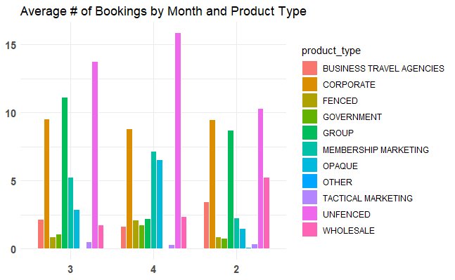

```r
h2_train %>%
  select(month, product_type, OTB_to_be_cxl) %>%
  group_by(month, product_type) %>%
  summarise(avg_bookings = mean(OTB_to_be_cxl)) %>%
  ggplot(aes(x = reorder(month, -avg_bookings), y = avg_bookings, fill = product_type)) +
           geom_bar(stat = "identity", width = .8, color = "white", position = "dodge") +
           theme_minimal() +
           theme(axis.title = element_blank(),
                axis.line.y = element_blank(),
                axis.ticks.y = element_blank(),
                axis.text.y = element_text(size = 11, face = "bold"),
                axis.text.x = element_text(size = 11, face = "bold")) +
           ggtitle("Average # of Bookings by Month and Product Type")
```

This is very different from hotel 1. April actually has the most stay dates while february has the least. However, this is not as steep of a decline as seen in hotel 1.

## 0.13 **CXL Rate**

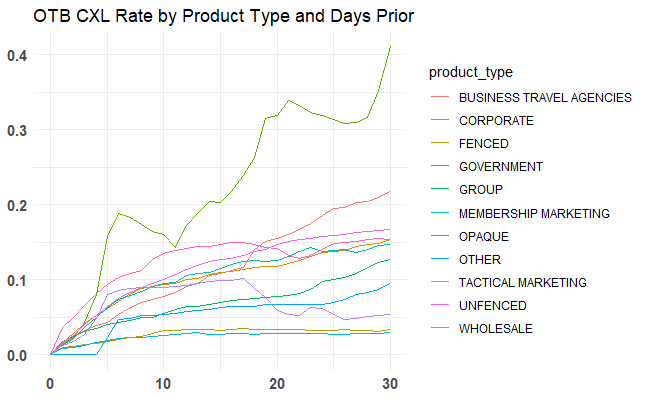

```r
h2_train %>%
  select(days_prior, OTB_cxl_rate, product_type) %>%
  group_by(days_prior, product_type) %>%
  summarise(avg_bookings = mean(OTB_cxl_rate)) %>%
  ggplot() +
  geom_line(aes(x = days_prior, y = avg_bookings,  color = product_type)) +
           theme_minimal() +
           theme(axis.title = element_blank(),
                axis.line.y = element_blank(),
                axis.ticks.y = element_blank(),
                axis.text.y = element_text(size = 11, face = "bold"),
                axis.text.x = element_text(size = 11, face = "bold")) +
           ggtitle("OTB CXL Rate by Product Type and Days Prior")
```

In this you can see that there are similar trends for different groups of product types. Government has a very dfferent cancellation rate than most.

The cancellation rate can also vary by days of week and product type.

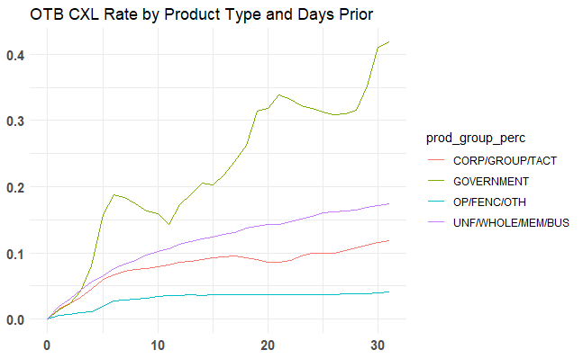

```r
#Look into our grouping methods and how the cancellation rate looks for days prior
h2_train_1 %>%
  select(prod_group_perc, OTB_cxl_rate, days_prior) %>%
  group_by(days_prior, prod_group_perc) %>%
  summarise(avg_bookings = mean(OTB_cxl_rate)) %>%
  ggplot() +
  geom_line(aes(x = days_prior, y = avg_bookings,  color = prod_group_perc)) +
           theme_minimal() +
           theme(axis.title = element_blank(),
                axis.line.y = element_blank(),
                axis.ticks.y = element_blank(),
                axis.text.y = element_text(size = 11, face = "bold"),
                axis.text.x = element_text(size = 11, face = "bold")) +
           ggtitle("OTB CXL Rate by Product Type and Days Prior")
```

Three of the groups follow a more log graph while government is parabolic.

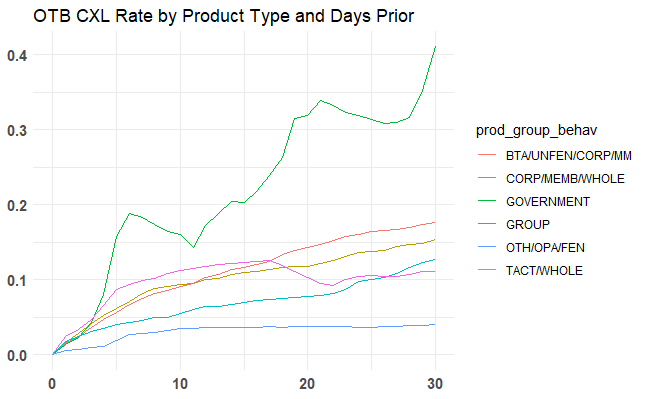

```r
h2_train_2 %>%
  select(prod_group_behav, OTB_cxl_rate, days_prior) %>%
  group_by(days_prior, prod_group_behav) %>%
  summarise(avg_bookings = mean(OTB_cxl_rate)) %>%
  ggplot() +
  geom_line(aes(x = days_prior, y = avg_bookings,  color = prod_group_behav)) +
           theme_minimal() +
           theme(axis.title = element_blank(),
                axis.line.y = element_blank(),
                axis.ticks.y = element_blank(),
                axis.text.y = element_text(size = 11, face = "bold"),
                axis.text.x = element_text(size = 11, face = "bold")) +
           ggtitle("OTB CXL Rate by Product Type and Days Prior")
```

This follows the same idea

## 0.14 **Outliers**

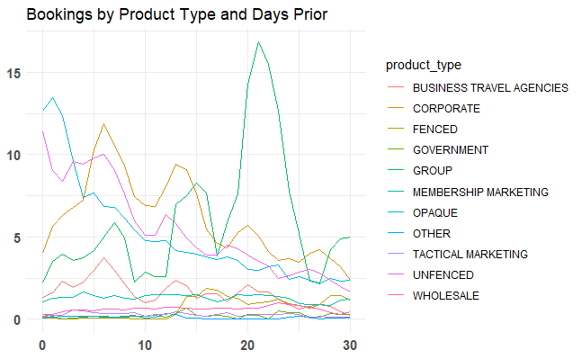

```r
h2_train %>%
  select(days_prior, daily_gross_bookings, product_type) %>%
  group_by(days_prior, product_type) %>%
  summarise(avg_bookings = mean(daily_gross_bookings)) %>%
  ggplot() +
  geom_line(aes(x = days_prior, y = avg_bookings,  color = product_type)) +
           theme_minimal() +
           theme(axis.title = element_blank(),
                axis.line.y = element_blank(),
                axis.ticks.y = element_blank(),
                axis.text.y = element_text(size = 11, face = "bold"),
                axis.text.x = element_text(size = 11, face = "bold")) +
           ggtitle("Bookings by Product Type and Days Prior")
```

There is a huge bump in group about 21 days out, should this be included?

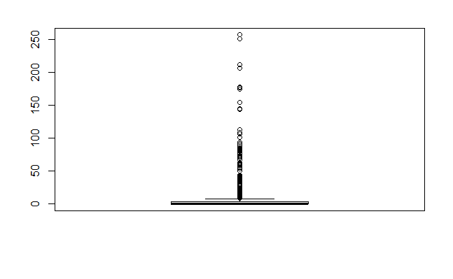

```r
#looking into outliers
group_outlier <- h2_train %>%
                filter(product_type == 'GROUP')
group_outlier <- boxplot(group_outlier$daily_gross_bookings)$out
```

```r
h2_train %>%
  select(product_type, days_prior, daily_gross_bookings) %>%
  filter(product_type == 'GROUP') %>%
  filter(daily_gross_bookings > 200)
```

| product_type | days_prior | daily_gross_bookings |
| --- | --- | --- |
| GROUP | 21 | 212 |
| GROUP | 22 | 251 |
| GROUP | 23 | 257 |
| GROUP | 24 | 206 |

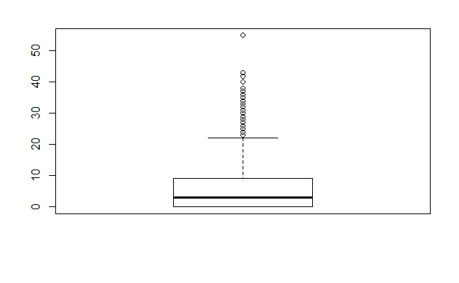

```r
corp_outlier <- h2_train %>%
                filter(product_type == 'CORPORATE')
corp_outlier <- boxplot(corp_outlier$daily_gross_bookings)$out
```

```r
h2_train %>%
  select(product_type, days_prior, daily_gross_bookings) %>%
  filter(product_type == 'CORPORATE') %>%
  filter(daily_gross_bookings > 50)
```

| product_type | days_prior | daily_gross_bookings |
| --- | --- | --- |
| CORPORATE | 5 | 55 |

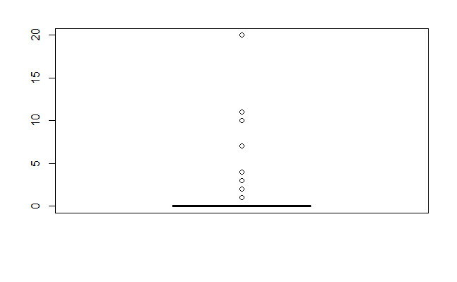

```r
gov_outlier <- h2_train %>%
                filter(product_type == 'GOVERNMENT')
gov_outlier <- boxplot(gov_outlier$daily_gross_bookings)$out
```

```r
h2_train %>%
  select(product_type, days_prior, daily_gross_bookings) %>%
  filter(product_type == 'GOVERNMENT') %>%
  filter(daily_gross_bookings > 10)
```

| product_type | days_prior | daily_gross_bookings |
| --- | --- | --- |
| GOVERNMENT | 23 | 11 |
| GOVERNMENT | 24 | 11 |
| GOVERNMENT | 14 | 20 |

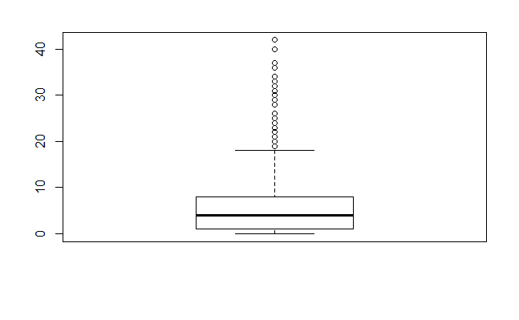

```r
unf_outlier <- h2_train %>%
                filter(product_type == 'UNFENCED')
unf_outlier <- boxplot(unf_outlier$daily_gross_bookings)$out
```

```r
h2_train %>%
  select(product_type, days_prior, daily_gross_bookings) %>%
  filter(product_type == 'UNFENCED') %>%
  filter(daily_gross_bookings > 30)
```

| product_type | days_prior | daily_gross_bookings |
| --- | --- | --- |
| UNFENCED | 4 | 33 |
| UNFENCED | 0 | 32 |
| UNFENCED | 1 | 42 |
| UNFENCED | 5 | 31 |
| UNFENCED | 15 | 31 |
| UNFENCED | 5 | 37 |
| UNFENCED | 6 | 33 |
| UNFENCED | 7 | 37 |
| UNFENCED | 6 | 42 |
| UNFENCED | 7 | 36 |

[output cut: 6 more lines]

```
Ignoring unknown aesthetics: fill
```

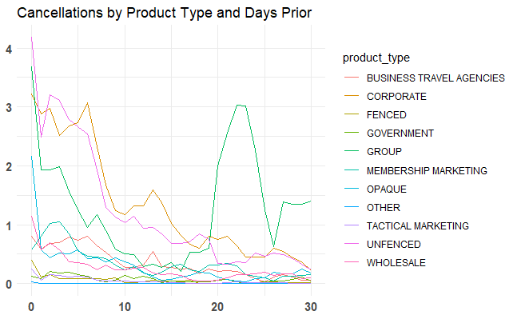

```r
#look into cancellations
h2_train %>%
  select(days_prior, daily_cxl_bookings, product_type) %>%
  group_by(days_prior, product_type) %>%
  summarise(avg_bookings = mean(daily_cxl_bookings)) %>%
  ggplot() +
  geom_line(aes(x = days_prior, y = avg_bookings, fill = product_type, color = product_type)) +
           theme_minimal() +
           theme(axis.title = element_blank(),
                axis.line.y = element_blank(),
                axis.ticks.y = element_blank(),
                axis.text.y = element_text(size = 11, face = "bold"),
                axis.text.x = element_text(size = 11, face = "bold")) +
           ggtitle("Cancellations by Product Type and Days Prior")
```

- seems to be similar bumps - look further into this?

## 0.15 **Correlations**

```r
#look into correlations to prepare for linear regressions
h2_train %>%
  select(dow, days_prior, cummulative_cxl_bookings, cummulative_gross_bookings, cummulative_gross_rev, OTB, OTB_rev, OTB_to_be_cxl, month, price)%>%
  cor()
```

```
                                    dow   days_prior cummulative_cxl_bookings
dow                         1.000000000  0.002853334             0.0198889649
days_prior                  0.002853334  1.000000000            -0.1687520164
cummulative_cxl_bookings    0.019888965 -0.168752016             1.0000000000
cummulative_gross_bookings  0.025979870 -0.199633926             0.6499099640
cummulative_gross_rev       0.005167109 -0.187635567             0.6130669251
OTB                         0.024848928 -0.187184628             0.5029930180
OTB_rev                     0.002487519 -0.174189404             0.4947361765
OTB_to_be_cxl              -0.019842709  0.093033507             0.3363546918
month                      -0.020348680  0.010817415            -0.0006114755
price                      -0.046268675  0.021358690             0.1059811850
                           cummulative_gross_bookings cummulative_gross_rev
dow                                        0.02597987           0.005167109
days_prior                                -0.19963393          -0.187635567
cummulative_cxl_bookings                   0.64990996           0.613066925
cummulative_gross_bookings                 1.00000000           0.955978015
cummulative_gross_rev                      0.95597802           1.000000000
OTB                                        0.98377062           0.942406744
OTB_rev                                    0.94150821           0.989287388
OTB_to_be_cxl                              0.59919344           0.676332675
month                                      0.13899544           0.183130855
price                                      0.12746212           0.241628022
                                   OTB      OTB_rev OTB_to_be_cxl
dow                         0.02484893  0.002487519   -0.01984271
days_prior                 -0.18718463 -0.174189404    0.09303351
cummulative_cxl_bookings    0.50299302  0.494736176    0.33635469
cummulative_gross_bookings  0.98377062  0.941508209    0.59919344
cummulative_gross_rev       0.94240674  0.989287388    0.67633267
OTB                         1.00000000  0.953888217    0.60199748
OTB_rev                     0.95388822  1.000000000    0.68422994
OTB_to_be_cxl               0.60199748  0.684229939    1.00000000
month                       0.15821102  0.195350427    0.02774043
price                       0.11992984  0.237485140    0.22478381
                                   month       price
dow                        -0.0203486796 -0.04626868
days_prior                  0.0108174148  0.02135869
cummulative_cxl_bookings   -0.0006114755  0.10598119
cummulative_gross_bookings  0.1389954383  0.12746212
cummulative_gross_rev       0.1831308546  0.24162802
OTB                         0.1582110227  0.11992984
OTB_rev                     0.1953504272  0.23748514
OTB_to_be_cxl               0.0277404329  0.22478381
month                       1.0000000000  0.24223664
price                       0.2422366405  1.00000000
```

```r
# Grouping Method 1:
# h2_train_1: prod_group_perc, dow, price, days_prior, price, one of (cummulative_gross_bookings,cummulative_gross_rev,cummulative_cxl_bookings,cummulative_cxl_rev,OTB,OTB_rev)
h2_train_1$month <- month(h2_train_1$stay_dt)
mod1 <- lm(OTB_cxl_rate~days_prior+day_of_week+month+prod_group_perc+price+cummulative_cxl_bookings, data=h2_train_1)
mod2 <- lm(OTB_cxl_rate~days_prior+day_of_week+month+prod_group_perc+price+cummulative_gross_bookings, data=h2_train_1)
mod3 <- lm(OTB_cxl_rate~days_prior+day_of_week+month+prod_group_perc+price+cummulative_gross_rev, data=h2_train_1)
mod4 <- lm(OTB_cxl_rate~days_prior+day_of_week+month+prod_group_perc+price+OTB, data=h2_train_1)
summary(mod1)
```

```
Call:
lm(formula = OTB_cxl_rate ~ days_prior + day_of_week + month +
    prod_group_perc + price + cummulative_cxl_bookings, data = h2_train_1)

Residuals:
     Min       1Q   Median       3Q      Max
-0.26542 -0.05363 -0.01314  0.02910  0.96439

Coefficients:
                                    Estimate  Std. Error t value
(Intercept)                       0.09951801  0.00483112  20.599
days_prior                        0.00364159  0.00008877  41.023
day_of_week2                      0.01519311  0.00307585   4.939
day_of_week3                      0.00295999  0.00306645   0.965
day_of_week4                      0.00170169  0.00299332   0.568
day_of_week5                      0.01005801  0.00297878   3.377
day_of_week6                      0.01281116  0.00295528   4.335
day_of_week7                      0.00940908  0.00295471   3.184
month                            -0.01477875  0.00125040 -11.819
prod_group_percGOVERNMENT         0.11685234  0.00368290  31.728
prod_group_percOP/FENC/OTH       -0.06536980  0.00245431 -26.635
prod_group_percUNF/WHOLE/MEM/BUS  0.03142592  0.00196685  15.978
price                            -0.00015852  0.00001145 -13.840
cummulative_cxl_bookings         -0.00011519  0.00003718  -3.098
                                             Pr(>|t|)
(Intercept)                      < 0.0000000000000002 ***
days_prior                       < 0.0000000000000002 ***
day_of_week2                              0.000000789 ***
day_of_week3                                 0.334415
day_of_week4                                 0.569705
day_of_week5                                 0.000735 ***
day_of_week6                              0.000014641 ***
day_of_week7                                 0.001452 **
month                            < 0.0000000000000002 ***
prod_group_percGOVERNMENT        < 0.0000000000000002 ***
prod_group_percOP/FENC/OTH       < 0.0000000000000002 ***
prod_group_percUNF/WHOLE/MEM/BUS < 0.0000000000000002 ***
price                            < 0.0000000000000002 ***
cummulative_cxl_bookings                     0.001948 **
---
Signif. codes:  0 *** 0.001 ** 0.01 * 0.05 . 0.1   1

Residual standard error: 0.1182 on 21734 degrees of freedom
Multiple R-squared:  0.1906,    Adjusted R-squared:  0.1902
F-statistic: 393.8 on 13 and 21734 DF,  p-value: < 0.00000000000000022
```

```r
summary(mod2)
```

```
Call:
lm(formula = OTB_cxl_rate ~ days_prior + day_of_week + month +
    prod_group_perc + price + cummulative_gross_bookings, data = h2_train_1)

Residuals:
     Min       1Q   Median       3Q      Max
-0.26536 -0.05395 -0.01310  0.02939  0.96400

Coefficients:
                                     Estimate   Std. Error t value
(Intercept)                       0.098034379  0.004792867  20.454
days_prior                        0.003650872  0.000089599  40.747
day_of_week2                      0.015481436  0.003076427   5.032
day_of_week3                      0.003312587  0.003069549   1.079
day_of_week4                      0.002031857  0.002996119   0.678
day_of_week5                      0.010204701  0.002981188   3.423
day_of_week6                      0.012933698  0.002956431   4.375
day_of_week7                      0.009535332  0.002957365   3.224
month                            -0.014415997  0.001262156 -11.422
prod_group_percGOVERNMENT         0.116768606  0.003738572  31.233
prod_group_percOP/FENC/OTH       -0.064370349  0.002431268 -26.476
prod_group_percUNF/WHOLE/MEM/BUS  0.031290836  0.001980278  15.801
price                            -0.000157512  0.000011502 -13.694
cummulative_gross_bookings       -0.000016207  0.000007933  -2.043
                                             Pr(>|t|)
(Intercept)                      < 0.0000000000000002 ***
days_prior                       < 0.0000000000000002 ***
day_of_week2                              0.000000489 ***
day_of_week3                                  0.28052
day_of_week4                                  0.49768
day_of_week5                                  0.00062 ***
day_of_week6                              0.000012213 ***
day_of_week7                                  0.00126 **
month                            < 0.0000000000000002 ***
prod_group_percGOVERNMENT        < 0.0000000000000002 ***
prod_group_percOP/FENC/OTH       < 0.0000000000000002 ***
prod_group_percUNF/WHOLE/MEM/BUS < 0.0000000000000002 ***
price                            < 0.0000000000000002 ***
cummulative_gross_bookings                    0.04108 *
---
Signif. codes:  0 *** 0.001 ** 0.01 * 0.05 . 0.1   1

Residual standard error: 0.1182 on 21734 degrees of freedom
Multiple R-squared:  0.1904,    Adjusted R-squared:   0.19
F-statistic: 393.3 on 13 and 21734 DF,  p-value: < 0.00000000000000022
```

```r
summary(mod3)
```

```
Call:
lm(formula = OTB_cxl_rate ~ days_prior + day_of_week + month +
    prod_group_perc + price + cummulative_gross_rev, data = h2_train_1)

Residuals:
     Min       1Q   Median       3Q      Max
-0.26638 -0.05346 -0.01335  0.02898  0.96529

Coefficients:
                                        Estimate      Std. Error t value
(Intercept)                       0.097392700843  0.004782784009  20.363
days_prior                        0.003698551467  0.000089456524  41.345
day_of_week2                      0.015321761445  0.003077967856   4.978
day_of_week3                      0.002984886515  0.003073104928   0.971
day_of_week4                      0.001723082171  0.002999821754   0.574
day_of_week5                      0.009925037931  0.002983472053   3.327
day_of_week6                      0.012773085899  0.002956740816   4.320
day_of_week7                      0.009253277523  0.002956809940   3.129
month                            -0.014826646201  0.001267286058 -11.700
prod_group_percGOVERNMENT         0.118683074399  0.003731020666  31.810
prod_group_percOP/FENC/OTH       -0.064289772520  0.002433520870 -26.418
prod_group_percUNF/WHOLE/MEM/BUS  0.031893445118  0.001975489339  16.145
price                            -0.000160408063  0.000011627917 -13.795
cummulative_gross_rev             0.000000009402  0.000000031162   0.302
                                             Pr(>|t|)
(Intercept)                      < 0.0000000000000002 ***
days_prior                       < 0.0000000000000002 ***
day_of_week2                              0.000000648 ***
day_of_week3                                  0.33141
day_of_week4                                  0.56571
day_of_week5                                  0.00088 ***
day_of_week6                              0.000015673 ***
day_of_week7                                  0.00175 **
month                            < 0.0000000000000002 ***
prod_group_percGOVERNMENT        < 0.0000000000000002 ***
prod_group_percOP/FENC/OTH       < 0.0000000000000002 ***
prod_group_percUNF/WHOLE/MEM/BUS < 0.0000000000000002 ***
price                            < 0.0000000000000002 ***
cummulative_gross_rev                         0.76287
---
Signif. codes:  0 *** 0.001 ** 0.01 * 0.05 . 0.1   1

Residual standard error: 0.1182 on 21734 degrees of freedom
Multiple R-squared:  0.1903,    Adjusted R-squared:  0.1898
F-statistic: 392.9 on 13 and 21734 DF,  p-value: < 0.00000000000000022
```

```r
summary(mod4)
```

```
Call:
lm(formula = OTB_cxl_rate ~ days_prior + day_of_week + month +
    prod_group_perc + price + OTB, data = h2_train_1)

Residuals:
     Min       1Q   Median       3Q      Max
-0.26557 -0.05389 -0.01314  0.02936  0.96425

Coefficients:
                                     Estimate   Std. Error t value
(Intercept)                       0.097690475  0.004786374  20.410
days_prior                        0.003662193  0.000089351  40.987
day_of_week2                      0.015486119  0.003077054   5.033
day_of_week3                      0.003290580  0.003070847   1.072
day_of_week4                      0.002011352  0.002997293   0.671
day_of_week5                      0.010166276  0.002981671   3.410
day_of_week6                      0.012914838  0.002956749   4.368
day_of_week7                      0.009489637  0.002957800   3.208
month                            -0.014456159  0.001265846 -11.420
prod_group_percGOVERNMENT         0.117167295  0.003736588  31.357
prod_group_percOP/FENC/OTH       -0.064234482  0.002431855 -26.414
prod_group_percUNF/WHOLE/MEM/BUS  0.031404735  0.001981077  15.852
price                            -0.000157944  0.000011508 -13.724
OTB                              -0.000014262  0.000009049  -1.576
                                             Pr(>|t|)
(Intercept)                      < 0.0000000000000002 ***
days_prior                       < 0.0000000000000002 ***
day_of_week2                              0.000000487 ***
day_of_week3                                 0.283932
day_of_week4                                 0.502192
day_of_week5                                 0.000652 ***
day_of_week6                              0.000012602 ***
day_of_week7                                 0.001337 **
month                            < 0.0000000000000002 ***
prod_group_percGOVERNMENT        < 0.0000000000000002 ***
prod_group_percOP/FENC/OTH       < 0.0000000000000002 ***
prod_group_percUNF/WHOLE/MEM/BUS < 0.0000000000000002 ***
price                            < 0.0000000000000002 ***
OTB                                          0.115024
---
Signif. codes:  0 *** 0.001 ** 0.01 * 0.05 . 0.1   1

Residual standard error: 0.1182 on 21734 degrees of freedom
Multiple R-squared:  0.1904,    Adjusted R-squared:  0.1899
F-statistic: 393.1 on 13 and 21734 DF,  p-value: < 0.00000000000000022
```

```r
# Grouping Method 2:
# h2_train_2: prod_group_behav, dow, price, days_prior, one of (cummulative_gross_bookings,cummulative_gross_rev,cummulative_cxl_bookings,cummulative_cxl_rev,OTB,OTB_rev)
h2_train_2$month <- month(h2_train_2$stay_dt)
mod1 <- lm(OTB_cxl_rate~days_prior+day_of_week+month+prod_group_behav+price+cummulative_cxl_bookings, data=h2_train_2)
mod2 <- lm(OTB_cxl_rate~days_prior+day_of_week+month+prod_group_behav+price+cummulative_gross_bookings, data=h2_train_2)
mod3 <- lm(OTB_cxl_rate~days_prior+day_of_week+month+prod_group_behav+price+cummulative_gross_rev, data=h2_train_2)
mod4 <- lm(OTB_cxl_rate~days_prior+day_of_week+month+prod_group_behav+price+OTB, data=h2_train_2)
summary(mod1)
```

```
Call:
lm(formula = OTB_cxl_rate ~ days_prior + day_of_week + month +
    prod_group_behav + price + cummulative_cxl_bookings, data = h2_train_2)

Residuals:
     Min       1Q   Median       3Q      Max
-0.26324 -0.05312 -0.01234  0.02819  0.96188

Coefficients:
                                   Estimate  Std. Error t value
(Intercept)                      0.12951818  0.00482556  26.840
days_prior                       0.00371843  0.00009242  40.232
day_of_week2                     0.01584892  0.00310138   5.110
day_of_week3                     0.00405240  0.00309142   1.311
day_of_week4                     0.00249004  0.00301817   0.825
day_of_week5                     0.01042025  0.00300328   3.470
day_of_week6                     0.01255014  0.00298005   4.211
day_of_week7                     0.00908675  0.00297967   3.050
month                           -0.01360508  0.00126106 -10.789
prod_group_behavCORP/MEMB/WHOLE -0.01084517  0.00296850  -3.653
prod_group_behavGOVERNMENT       0.08345984  0.00367130  22.733
prod_group_behavGROUP           -0.04394841  0.00301316 -14.585
prod_group_behavOTH/OPA/FEN     -0.09533169  0.00243197 -39.199
prod_group_behavTACT/WHOLE      -0.01280178  0.00238842  -5.360
price                           -0.00017927  0.00001160 -15.460
cummulative_cxl_bookings        -0.00008452  0.00003821  -2.212
                                            Pr(>|t|)
(Intercept)                     < 0.0000000000000002 ***
days_prior                      < 0.0000000000000002 ***
day_of_week2                            0.0000003245 ***
day_of_week3                                0.189921
day_of_week4                                0.409372
day_of_week5                                0.000522 ***
day_of_week6                            0.0000254857 ***
day_of_week7                                0.002294 **
month                           < 0.0000000000000002 ***
prod_group_behavCORP/MEMB/WHOLE             0.000259 ***
prod_group_behavGOVERNMENT      < 0.0000000000000002 ***
prod_group_behavGROUP           < 0.0000000000000002 ***
prod_group_behavOTH/OPA/FEN     < 0.0000000000000002 ***
prod_group_behavTACT/WHOLE              0.0000000841 ***
price                           < 0.0000000000000002 ***
cummulative_cxl_bookings                    0.026974 *
---
Signif. codes:  0 *** 0.001 ** 0.01 * 0.05 . 0.1   1

Residual standard error: 0.1174 on 21106 degrees of freedom
Multiple R-squared:  0.1856,    Adjusted R-squared:  0.1851
F-statistic: 320.8 on 15 and 21106 DF,  p-value: < 0.00000000000000022
```

```r
summary(mod2)
```

```
Call:
lm(formula = OTB_cxl_rate ~ days_prior + day_of_week + month +
    prod_group_behav + price + cummulative_gross_bookings, data = h2_train_2)

Residuals:
     Min       1Q   Median       3Q      Max
-0.26370 -0.05310 -0.01250  0.02821  0.96219

Coefficients:
                                    Estimate   Std. Error t value
(Intercept)                      0.128249293  0.004791270  26.767
days_prior                       0.003748581  0.000093635  40.034
day_of_week2                     0.015996550  0.003102012   5.157
day_of_week3                     0.004179334  0.003094524   1.351
day_of_week4                     0.002612115  0.003020839   0.865
day_of_week5                     0.010410747  0.003005756   3.464
day_of_week6                     0.012565592  0.002981336   4.215
day_of_week7                     0.009040452  0.002982995   3.031
month                           -0.013517127  0.001273689 -10.613
prod_group_behavCORP/MEMB/WHOLE -0.011281970  0.002987809  -3.776
prod_group_behavGOVERNMENT       0.084178424  0.003706270  22.712
prod_group_behavGROUP           -0.044600913  0.003106081 -14.359
prod_group_behavOTH/OPA/FEN     -0.094706693  0.002430680 -38.963
prod_group_behavTACT/WHOLE      -0.012260417  0.002418140  -5.070
price                           -0.000180171  0.000011709 -15.388
cummulative_gross_bookings      -0.000003189  0.000008661  -0.368
                                            Pr(>|t|)
(Intercept)                     < 0.0000000000000002 ***
days_prior                      < 0.0000000000000002 ***
day_of_week2                             0.000000253 ***
day_of_week3                                0.176852
day_of_week4                                0.387214
day_of_week5                                0.000534 ***
day_of_week6                             0.000025109 ***
day_of_week7                                0.002443 **
month                           < 0.0000000000000002 ***
prod_group_behavCORP/MEMB/WHOLE             0.000160 ***
prod_group_behavGOVERNMENT      < 0.0000000000000002 ***
prod_group_behavGROUP           < 0.0000000000000002 ***
prod_group_behavOTH/OPA/FEN     < 0.0000000000000002 ***
prod_group_behavTACT/WHOLE               0.000000401 ***
price                           < 0.0000000000000002 ***
cummulative_gross_bookings                  0.712759
---
Signif. codes:  0 *** 0.001 ** 0.01 * 0.05 . 0.1   1

Residual standard error: 0.1174 on 21106 degrees of freedom
Multiple R-squared:  0.1855,    Adjusted R-squared:  0.1849
F-statistic: 320.4 on 15 and 21106 DF,  p-value: < 0.00000000000000022
```

```r
summary(mod3)
```

```
Call:
lm(formula = OTB_cxl_rate ~ days_prior + day_of_week + month +
    prod_group_behav + price + cummulative_gross_rev, data = h2_train_2)

Residuals:
     Min       1Q   Median       3Q      Max
-0.26498 -0.05284 -0.01264  0.02770  0.96278

Coefficients:
                                      Estimate     Std. Error t value
(Intercept)                      0.12890623839  0.00480015234  26.855
days_prior                       0.00380680604  0.00009350175  40.714
day_of_week2                     0.01570439978  0.00310322695   5.061
day_of_week3                     0.00367568828  0.00309800706   1.186
day_of_week4                     0.00212773703  0.00302446946   0.704
day_of_week5                     0.01000015115  0.00300777554   3.325
day_of_week6                     0.01236606415  0.00298104969   4.148
day_of_week7                     0.00872939141  0.00298163952   2.928
month                           -0.01406751183  0.00127987701 -10.991
prod_group_behavCORP/MEMB/WHOLE -0.01226022936  0.00297935763  -4.115
prod_group_behavGOVERNMENT       0.08597951489  0.00371239149  23.160
prod_group_behavGROUP           -0.04674659345  0.00309264149 -15.115
prod_group_behavOTH/OPA/FEN     -0.09495401344  0.00242077023 -39.225
prod_group_behavTACT/WHOLE      -0.01076006357  0.00243938931  -4.411
price                           -0.00018693093  0.00001189969 -15.709
cummulative_gross_rev            0.00000007605  0.00000003434   2.214
                                            Pr(>|t|)
(Intercept)                     < 0.0000000000000002 ***
days_prior                      < 0.0000000000000002 ***
day_of_week2                             0.000000421 ***
day_of_week3                                0.235451
day_of_week4                                0.481747
day_of_week5                                0.000886 ***
day_of_week6                             0.000033637 ***
day_of_week7                                0.003418 **
month                           < 0.0000000000000002 ***
prod_group_behavCORP/MEMB/WHOLE          0.000038855 ***
prod_group_behavGOVERNMENT      < 0.0000000000000002 ***
prod_group_behavGROUP           < 0.0000000000000002 ***
prod_group_behavOTH/OPA/FEN     < 0.0000000000000002 ***
prod_group_behavTACT/WHOLE               0.000010342 ***
price                           < 0.0000000000000002 ***
cummulative_gross_rev                       0.026813 *
---
Signif. codes:  0 *** 0.001 ** 0.01 * 0.05 . 0.1   1

Residual standard error: 0.1174 on 21106 degrees of freedom
Multiple R-squared:  0.1856,    Adjusted R-squared:  0.1851
F-statistic: 320.8 on 15 and 21106 DF,  p-value: < 0.00000000000000022
```

```r
summary(mod4)
```

```
Call:
lm(formula = OTB_cxl_rate ~ days_prior + day_of_week + month +
    prod_group_behav + price + OTB, data = h2_train_2)

Residuals:
     Min       1Q   Median       3Q      Max
-0.26396 -0.05301 -0.01253  0.02811  0.96249

Coefficients:
                                    Estimate   Std. Error t value
(Intercept)                      0.128251081  0.004792293  26.762
days_prior                       0.003760329  0.000093323  40.294
day_of_week2                     0.015956944  0.003102646   5.143
day_of_week3                     0.004104816  0.003095875   1.326
day_of_week4                     0.002543891  0.003022031   0.842
day_of_week5                     0.010348981  0.003006169   3.443
day_of_week6                     0.012524913  0.002981589   4.201
day_of_week7                     0.008966089  0.002983398   3.005
month                           -0.013613943  0.001277822 -10.654
prod_group_behavCORP/MEMB/WHOLE -0.011504420  0.002986463  -3.852
prod_group_behavGOVERNMENT       0.084522244  0.003702800  22.827
prod_group_behavGROUP           -0.045055391  0.003108302 -14.495
prod_group_behavOTH/OPA/FEN     -0.094839859  0.002441445 -38.846
prod_group_behavTACT/WHOLE      -0.012003280  0.002415073  -4.970
price                           -0.000181093  0.000011718 -15.454
OTB                              0.000001497  0.000009868   0.152
                                            Pr(>|t|)
(Intercept)                     < 0.0000000000000002 ***
days_prior                      < 0.0000000000000002 ***
day_of_week2                             0.000000273 ***
day_of_week3                                0.184888
day_of_week4                                0.399920
day_of_week5                                0.000577 ***
day_of_week6                             0.000026712 ***
day_of_week7                                0.002656 **
month                           < 0.0000000000000002 ***
prod_group_behavCORP/MEMB/WHOLE             0.000117 ***
prod_group_behavGOVERNMENT      < 0.0000000000000002 ***
prod_group_behavGROUP           < 0.0000000000000002 ***
prod_group_behavOTH/OPA/FEN     < 0.0000000000000002 ***
prod_group_behavTACT/WHOLE               0.000000674 ***
price                           < 0.0000000000000002 ***
OTB                                         0.879425
---
Signif. codes:  0 *** 0.001 ** 0.01 * 0.05 . 0.1   1

Residual standard error: 0.1174 on 21106 degrees of freedom
Multiple R-squared:  0.1855,    Adjusted R-squared:  0.1849
F-statistic: 320.4 on 15 and 21106 DF,  p-value: < 0.00000000000000022
```